# Statistical Analysis

network analytics statistics CUG test statnet

Using Univariate Conditional Uniform Graph Tests

Kristina Becvar http://gratefulnetwork.live/ (UMass DACSS Program (My Academic Blog Link))https://kristinabecvar.com  
2022-05-10

```r
library(ggplot2)
library(readr)
library(statnet)
library(ggraph)
library(tidyverse)
library(ergm)
library(dplyr)
library(corrr)
library(magrittr)

suppressWarnings(expr)
```

# Loading Networks

I previously analyzed the network using igraph and statnet, and need to make a decision about which package serves the network best.

## Affiliation Matrix

Loading the dataset and creating the network to begin my analysis:

```r
gd_affiliation <- read.csv('gd_affiliation_matrix.csv', row.names = 1, header = TRUE, check.names = FALSE)
gd_matrix <- as.matrix(gd_affiliation)
```

## Bipartite Projection

```r
gd_projection <- gd_matrix%*%t(gd_matrix)
write.csv(gd_projection, file = "gd_projection.csv")
```

## Create statnet Object

```r
set.seed(11)
gd_statnet <- as.network(gd_projection,
               directed = FALSE,
               bipartite = FALSE,
               loops = FALSE,
               connected = TRUE)
```

# Centrality and Node Data

I am going to load the data frame I saved from the statnet package analysis as well as a dataframe with key comparable results from each package

```r
gd_stat_nodes <- read.csv("gd_stat_nodes.csv")
gd_compare <- read.csv("gd_comparison_packages.csv")
```

# Comparing Network Properties

In the semester assignment, we looked at what to do if we are interested in testing whether or not a specific network property, such as transitivity, is higher in the network we are interested in than we would expect from a random network. To test our network against a null hypothesis, we can use the function cug.test() and set the parameters on which we plan to condition. Possible parameters for this function include: size, edges, and dyad.census for sna/statnet.

## Create t-stat Function

```r
cug.t<-function(cug.object){
  (cug.object$obs.stat-mean(cug.object$rep.stat))/sd(cug.object$rep.stat)
}
```

## Network Transitivity to Null

Comparing transitivity to null conditional on size

```r
#compare network transitivity to null conditional on size
trans.cug<-cug.test(gd_projection,FUN=gtrans,mode="graph",cmode="size")
trans.cug
```

```
Univariate Conditional Uniform Graph Test

Conditioning Method: size
Graph Type: graph
Diagonal Used: FALSE
Replications: 1000

Observed Value: 0.5240964
Pr(X>=Obs): 0.189
Pr(X<=Obs): 0.811
```

### Plot Results

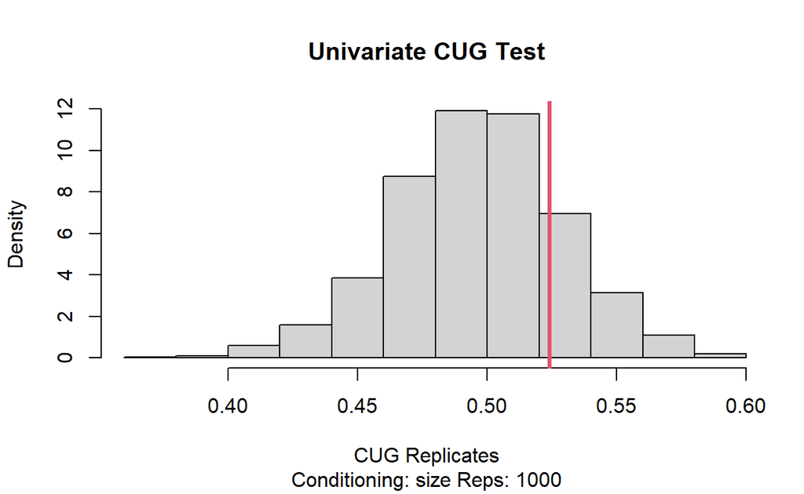

```r
plot(trans.cug)
```

### Inspect Details

```r
#inspect CUG test
trans.cug
```

```
Univariate Conditional Uniform Graph Test

Conditioning Method: size
Graph Type: graph
Diagonal Used: FALSE
Replications: 1000

Observed Value: 0.5240964
Pr(X>=Obs): 0.189
Pr(X<=Obs): 0.811
```

### T-Stat Test

```r
#inspect CUG test
cug.t(trans.cug)
```

```
[1] 0.8395548
```

## Network Degree Centralization to Null

Comparing network degree centralization to null conditional on size

```r
#compare network degree centralization to null conditional on size
c.degree.cug <-cug.test(gd_projection,FUN=centralization,  FUN.arg=list(FUN=degree, cmode="degree"), mode="graph", cmode="size")
```

### Plot Results

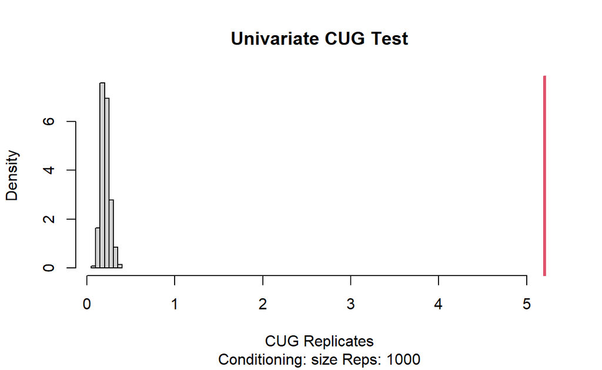

```r
#plot vs simulation results
plot(c.degree.cug)
```

### Inspect Details

```r
#inspect CUG test
c.degree.cug
```

```
Univariate Conditional Uniform Graph Test

Conditioning Method: size
Graph Type: graph
Diagonal Used: FALSE
Replications: 1000

Observed Value: 5.206522
Pr(X>=Obs): 0
Pr(X<=Obs): 1
```

### T-Stat Test

```r
#t-stat between observed and simulated networks
cug.t(c.degree.cug)
```

```
[1] 101.9499
```

### Evaluation

There is an extremely remote probability that the observed network degree centrality of 5.21 could be randomly generated, conditional only on the size of the network. In this case, I can accept the alternative hypothesis that the observed network degree centrality is higher than would be expected from a random network. .

## Betweenness Centrality

Comparing network betweenness centralization to null conditional on size

```r
#compare network betweenness centralization to null conditional on size
b.degree.cug <-cug.test(gd_projection,FUN=centralization,  FUN.arg=list(FUN=betweenness, cmode="undirected"), mode="graph", cmode="size", reps=100)
```

### Plot Results

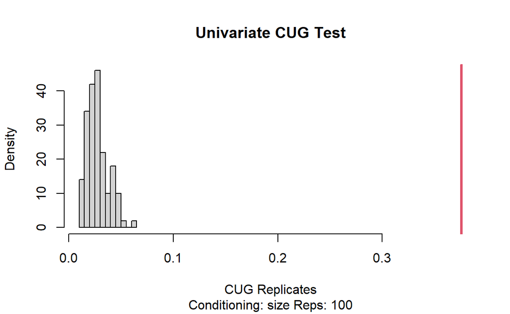

```r
#plot vs simulation results
plot(b.degree.cug)
```

### Inspect Details

```r
#inspect CUG test
b.degree.cug
```

```
Univariate Conditional Uniform Graph Test

Conditioning Method: size
Graph Type: graph
Diagonal Used: FALSE
Replications: 100

Observed Value: 0.3759561
Pr(X>=Obs): 0
Pr(X<=Obs): 1
```

### T-Stat Test

```r
#t-stat between observed and simulated networks
cug.t(b.degree.cug)
```

```
[1] 34.06653
```

## Transitivity

Comparing transitivity to null conditional on dyad

```r
t.degree.cug <-cug.test(gd_projection,FUN=gtrans, mode="graph", cmode="dyad", reps=100)
```

### Plot Results

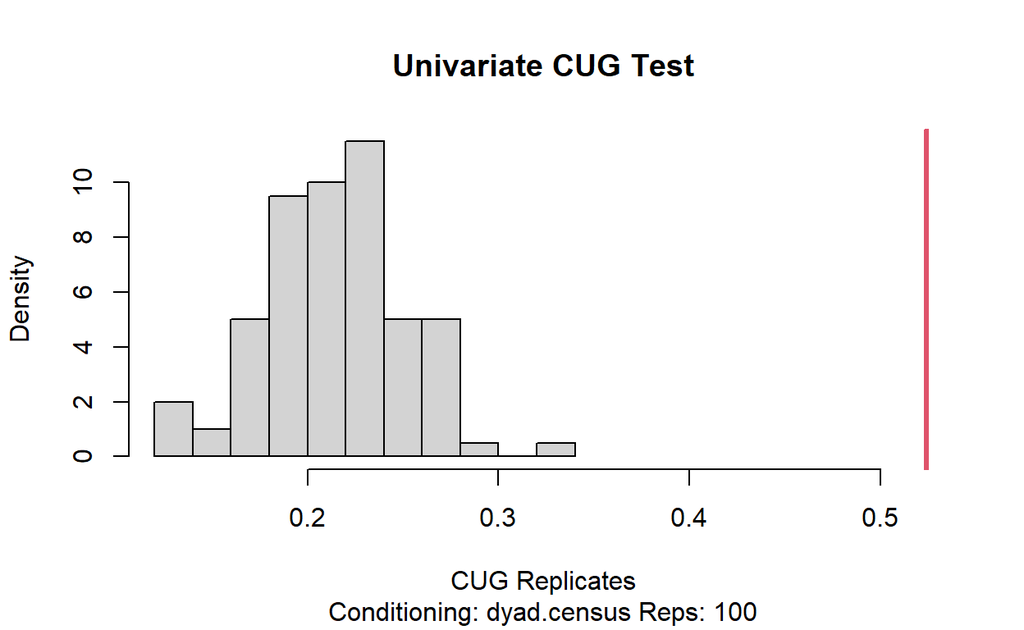

```r
#plot vs simulation results
plot(t.degree.cug)
```

### Inspect Details

```r
#inspect CUG test
t.degree.cug
```

```
Univariate Conditional Uniform Graph Test

Conditioning Method: dyad.census
Graph Type: graph
Diagonal Used: FALSE
Replications: 100

Observed Value: 0.5240964
Pr(X>=Obs): 0
Pr(X<=Obs): 1
```

### T-Stat Test

```r
#t-stat between observed and simulated networks
cug.t(t.degree.cug)
```

```
[1] 8.463895
```

### Evaluation

Unlike the first evaluation of transitivity on size, this evaluation of transitivity on dyad gives a result that is more in line with subsequent calculations.

## Multiple Evaluations

For my research in particular, I want to look at the measures of centrality and through the different modes of evaluation.

```r
cug_cent_size <- cug.test(gd_statnet,
                       centralization,
                       FUN.arg=list(FUN=degree),
                       mode="graph",
                       cmode="size")
cug_cent_edge <- cug.test(gd_statnet,
                        centralization,
                        FUN.arg=list(FUN=degree),
                        mode="graph",
                        cmode="edges")
cug_cent_dyad <- cug.test(gd_statnet,
                       centralization,
                       FUN.arg=list(FUN=degree),
                       mode="graph",
                       cmode="dyad.census")

cug_cent_dyad
```

```
Univariate Conditional Uniform Graph Test

Conditioning Method: dyad.census
Graph Type: graph
Diagonal Used: FALSE
Replications: 1000

Observed Value: 0.5344203
Pr(X>=Obs): 0
Pr(X<=Obs): 1
```

### Visualization

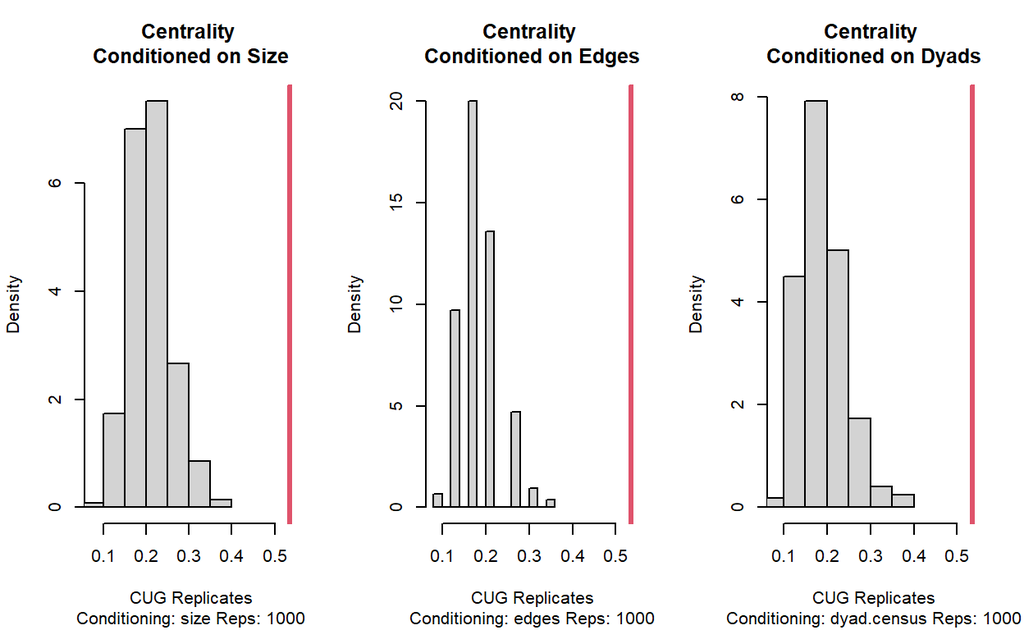

```r
degree_centralization <- c(cug_cent_size$obs.stat,
                        cug_cent_edge$obs.stat,
                        cug_cent_dyad$obs.stat)

rt_tail <- c(cug_cent_size$pgteobs,
             cug_cent_edge$pgteobs,
             cug_cent_dyad$pgteobs)

lt_tail <- c(cug_cent_size$plteobs,
             cug_cent_edge$plteobs,
             cug_cent_dyad$plteobs)

centrality <- cbind(degree_centralization,
                     rt_tail,
                     lt_tail)

rownames(centrality) <- c("Size", "Edges", "Dyads")

par(mfrow=c(1,3))
plot(cug_cent_size, main="Centrality \nConditioned on Size" )
plot(cug_cent_edge, main="Centrality \nConditioned on Edges" )
plot(cug_cent_dyad, main="Centrality \nConditioned on Dyads" )
```